# Accounting for gene-ex probe hybridization efficiency

23 February 2022

# 1 QTL region

```r
    ci_chr = '13'; ci_lo = 83.78112; ci_hi = 93.41913; ci_mid = 90.4
```

# 2 Load EMBL annotated proteins

1. To check if some genes we don’t have expression data for that could drop out in this analysis

```r
    embl_genes = readRDS('../data/analysis_cache/embl_genes.rds')
```

# 3 Load eQTL trace data

```r
    # load eQTL traces and %expanded QTL traces for all probes
    all_trace   = readRDS('../data/gene_expr/qtl_agg/gene_expr_db.rds')
    perc_expand = readRDS('../data/gene_expr/qtl_agg/perc_expand_db.rds')

    # load eQTL traces and %expanded QTL traces data for probes overlapping at least one snp
    # snps per probe was used as a covariate
    # NOTE: no need to reload perc_expand for snps_covar, becuase this is the same
    all_trace_snps_covar = readRDS('../data/gene_expr/qtl_agg_snps_covar/gene_expr_db.rds')

    # I think this embedded list breaks things
    all_trace$probes$alig_data = NULL
    all_trace_snps_covar$probes$alig_data = NULL

    # only interested in prot genes even for original analysis
    prot_genes = embl_genes %>% filter(gene_type == 'protein_coding') %>% pull(gene_name)

    # load information of number of snps per probe
    probe_info = all_trace$probes %>%
        left_join(all_trace$signal %>% distinct(probe, gene_name), by = 'probe')

    # join probe information onto traces
    # NOTE: the inner join to get rid of probe for which # of snps can't be known
    eqtl_data = map(list(all = all_trace, snps_covar = all_trace_snps_covar), function(.x) {
        # genes not included in this join
        .z = map(c('signal', 'expr_vals') %>% set_names(.), function(.y) {
            if ('gene_name' %in% names(.x[[.y]])) {
                .x[[.y]] %>%
                    inner_join(probe_info, by = c('probe', 'gene_name')) %>%
                    filter(gene_name %in% prot_genes)
            } else {
                .x[[.y]] %>% inner_join(probe_info, by = 'probe')
            }
        })
        .z$probes = .x$probes %>%
            left_join(.x$signal %>% distinct(probe, gene_name), by = 'probe') %>%
            filter(gene_name %in% prot_genes)
        .z
    })

    # collate data by type with each element being and analysis
    traces = list(
        all = eqtl_data$all$signal,
        snp_mask = eqtl_data$all$signal %>% filter(n_var_per_probe == 0),
        snps_covar = eqtl_data$snps_covar$signal
    )
    expr_vals = list(
        all = eqtl_data$all$expr_vals,
        snp_mask = eqtl_data$all$expr_vals %>% filter(n_var_per_probe == 0),
        # snps_covar = eqtl_data$all$expr_vals %>% filter(n_var_per_probe != 0)
        snps_covar = eqtl_data$snps_covar$expr_vals
    )
    probes = list(
        all = eqtl_data$all$probes,
        snp_mask = eqtl_data$all$probes %>% filter(n_var_per_probe == 0),
        # snps_covar = eqtl_data$all$probes %>% filter(n_var_per_probe != 0)
        snps_covar = eqtl_data$snps_covar$probes
    )
    genes = list(
        all = all_trace$genes, # %>% filter(gene_name %in% prot_genes),
        snp_mask = all_trace$genes %>% semi_join(probes$snp_mask, by = 'gene_name'),
        snps_covar = all_trace_snps_covar$genes
    )
    markers = all_trace$marker

    # define DNA repair genes
    dna_repair_genes = c('Msh3', 'Xrcc4', 'Ssbp2', 'Atg10', 'Ccnh')
```

# 4 Load list of representative datasets

```r
    gn_table  = readRDS('../data/analysis_cache/final_gn_table.rds')
    sel_dsets = gn_table %>% select(GN = sel_dset) %>% distinct(GN) %>% filter(!is.na(GN)) %>% pull(GN)
```

# 5 Filter to representative datasets

```r
    traces     = map(traces, ~.x %>% filter(GN %in% sel_dsets))
```

# 6 Best trace for each dset/gene pair

1. Calculate best point within QTL sized region around gene
2. Take the trace that is associated with that point

```r
    # convert position
    genes = map(genes, ~.x %>% mutate(across(c(gene_pos, gene_end), ~.x/1e6)))

    # best point within QTL sized region around gene
    # .x = 'all'
    analyses = c('all', 'snp_mask', 'snps_covar') %>% set_names(.)
    ci_hwind = (ci_hi - ci_lo)/2
    best_point = map(analyses, function(.x) {
        traces[[.x]] %>%
            left_join(genes[[.x]], by = 'gene_name') %>%
            left_join(markers, by = 'marker') %>%
            arrange(desc(LOD)) %>%
            filter(mark_pos >= (gene_end+gene_pos)/2 - ci_hwind, mark_pos <= (gene_end+gene_pos)/2 + ci_hwind) %>%
            distinct(GN, gene_name, mark_chr, .keep_all = TRUE) %>%
            # left_join(all_trace$probes, by = 'probe') %>%
            mutate(across(where(is.factor), as.character))
    })

    # best trace from best point
    best_trace = map(analyses, function(.x) {
        traces[[.x]] %>%
            semi_join(best_point[[.x]], by = c('GN', 'gene_name', 'probe'))
    })
```

# 7 Probes overlapping variants

1. Compare eQTL mapping results when either using variants-per-probe as covariate or not (fill)
2. Data from multiple datasets and probes combined for each gene
   - “All traces”: all probes per dset/gene pair
   - “Best traces”: best probe per dset/gene pair

```r
    # "covar_comp" is a data.frame comparing eQTL w/ and w/o snps as a covariate

    # all traces
    covar_comp = list(
        wo_snps_covar = traces$all %>% semi_join(traces$snps_covar, by = c('GN', 'probe', 'gene_name')),
        w_snps_covar = traces$snps_covar
    ) %>% map_df(~.x, .id = 'analysis') %>%
        mutate(analysis = fct_relevel(analysis, c('wo_snps_covar', 'w_snps_covar'))) %>%
        left_join(markers, by = 'marker')

    # best trace
    covar_comp_best = list(
        wo_snps_covar = best_trace$all %>% semi_join(traces$snps_covar, by = c('GN', 'probe', 'gene_name')),
        w_snps_covar = best_trace$snps_covar
    ) %>% map_df(~.x, .id = 'analysis') %>%
        mutate(analysis = fct_relevel(analysis, c('wo_snps_covar', 'w_snps_covar'))) %>%
        left_join(markers, by = 'marker')

    # check
    # covar_comp %>% distinct(GN)
    # covar_comp_best %>% distinct(GN)
```

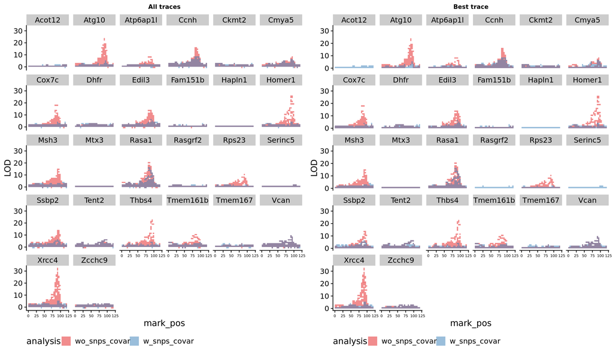

```r
    p1 = covar_comp %>%
        ggplot(aes(mark_pos, LOD, fill = analysis)) +
        geom_bin2d(alpha = 0.5) +
        scale_fill_brewer(palette = 'Set1') +
        facet_wrap(~gene_name) +
        theme_half_open() +
        theme(plot.title = element_text(size = 10, hjust = 0.5),
              legend.position = 'bottom',
              axis.text.x = element_text(size = 6)) +
        labs(title = 'All traces')
    p2 = ( p1 %+% covar_comp_best) + labs(title = 'Best trace')
    p = plot_grid(p1, p2, nrow = 1)
    p
```

```r
    ggsave('test.pdf', p, w = 14, h = 8)
```

# 8 Msh3 as example by dataset

1. Still probes overlapping variants
2. Most panels will have two traces if one probe per dset/gene
3. GN206, GN163, GN151 are example that have many probes per dset/gene

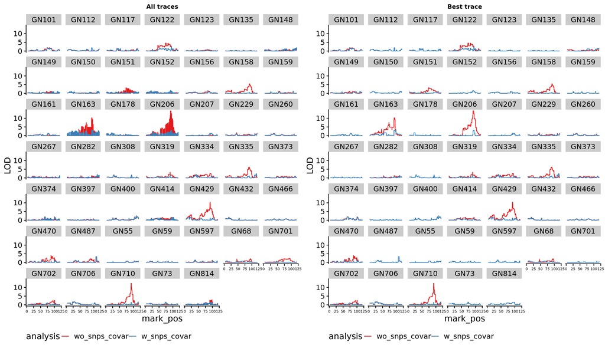

```r
    gene_name = 'Msh3'
    p1 = covar_comp %>%
        filter(gene_name == !!gene_name) %>%
        ggplot(aes(mark_pos, LOD, color = analysis)) +
        geom_step() +
        scale_color_brewer(palette = 'Set1') +
        facet_wrap(~GN) +
        theme_half_open() +
        theme(plot.title = element_text(size = 10, hjust = 0.5),
              legend.position = 'bottom',
              axis.text.x = element_text(size = 6)) +
        labs(title = 'All traces')
    p2 = ( p1 %+% ( covar_comp_best %>% filter(gene_name == !!gene_name) )) + labs(title = 'Best trace')
    p = plot_grid(p1, p2, nrow = 1)
    p
```

```r
    ggsave('test.pdf', p, w = 14, h = 8)
```

# 9 Probes not overlapping variants

1. Fill simply highlights probe type
2. Some array probes don’t overlap with variants and RNAseq datasets assumed not affected by variants

```r
    # "all" is all probes per gene/GN
    # "best" is best probe per gene/GN
    snp_mask_comp = list(
        all  = traces$snp_mask,
        best = best_trace$snp_mask) %>%
        map(function(.x) {
            .x %>%
                filter(GN %in% sel_dsets) %>%
                left_join(markers, by = 'marker')
        })

    # check
    # snp_mask_comp %>% map(~distinct(.x, GN))
```

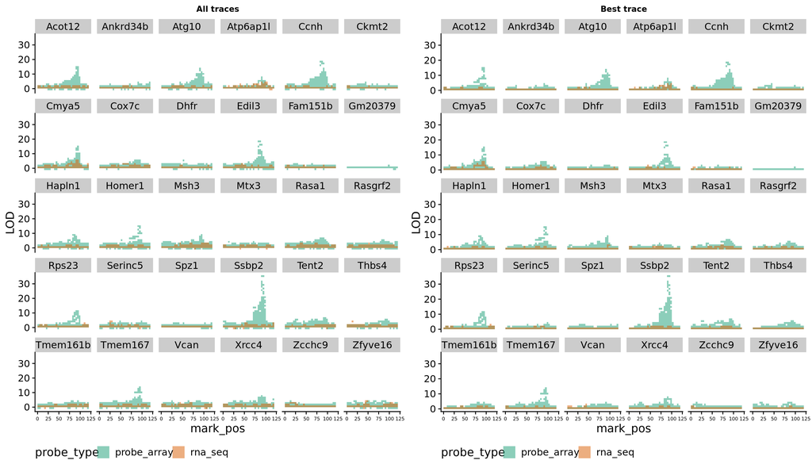

```r
    p1 = snp_mask_comp$all %>%
        ggplot(aes(mark_pos, LOD, fill = probe_type)) +
        geom_bin2d(alpha = 0.5) +
        facet_wrap(~gene_name) +
        scale_fill_brewer(palette = 'Dark2') +
        theme_half_open() +
        theme(plot.title = element_text(size = 10, hjust = 0.5),
              legend.position = 'bottom',
              axis.text.x = element_text(size = 6)) +
        labs(title = 'All traces')
    p2 = ( p1 %+% snp_mask_comp$best ) + labs(title = 'Best trace')
    p = plot_grid(p1, p2, nrow = 1)
    p
```

```r
    ggsave('test.pdf', p, w = 14, h = 8)
```

# 10 Count probes w/ and w/o variants by type

Most probes don’t contain variants

```r
   probes$all %>%
       count(probe_type, is_probeset, n_var_per_probe == 0) %>%
       mutate(prop = n/sum(n)) %>%
       arrange(desc(prop)) %>%
       rename(n_probes = 'n')
```

| probe_type | is_probeset | n_var_per_probe == 0 | n_probes | prop |
| --- | --- | --- | --- | --- |
| probe_array | TRUE | TRUE | 2244 | 0.516574586 |
| probe_array | FALSE | TRUE | 1215 | 0.279696133 |
| rna_seq | FALSE | TRUE | 385 | 0.088627993 |
| probe_array | TRUE | FALSE | 374 | 0.086095764 |
| probe_array | FALSE | FALSE | 103 | 0.023710866 |
| proteome | FALSE | TRUE | 23 | 0.005294659 |

```r
   # probes$all %>% count(n_var_per_probe == 0) %>% mutate(prop = n/sum(n))
```

Probes can be over-represented in data, but still majority have no variants

```r
   best_point$all %>%
       count(probe_type, is_probeset, n_var_per_probe == 0) %>%
       mutate(prop = n/sum(n)) %>%
       arrange(desc(prop)) %>%
       rename(n_traces = 'n')
```

| probe_type | is_probeset | n_var_per_probe == 0 | n_traces | prop |
| --- | --- | --- | --- | --- |
| probe_array | TRUE | TRUE | 814 | 0.59896983 |
| probe_array | TRUE | FALSE | 287 | 0.21118469 |
| probe_array | FALSE | TRUE | 192 | 0.14128035 |
| rna_seq | FALSE | TRUE | 50 | 0.03679176 |
| probe_array | FALSE | FALSE | 16 | 0.01177336 |

```r
   # best_point$all %>% count(n_var_per_probe == 0) %>% mutate(prop = n/sum(n))
```

# 11 Combine datasets accounting for variants in probes

1. Probes without variants
2. Probes with variants eQTL mapped with variants-per-probe as a covariate

```r
    # combine eQTL traces
    best_trace_recomb = bind_rows(
        covar_comp_best %>% filter(analysis == 'w_snps_covar') %>% select(!analysis),
        snp_mask_comp$best
    )

    # split into two analysis again:
    #   - "all": using all probes
    #   - "no_snp_probes": using only probes with variants
    best_trace_recomb = list(
        all_probes    = best_trace_recomb,
        no_snp_probes = best_trace_recomb %>% filter(n_var_per_probe == 0)
    )

    # take the best point within QTL sized region around each gene
    best_point_recomb = map(best_trace_recomb, function(.x) {
        .x %>%
            left_join(genes$all, by = 'gene_name') %>%
            arrange(desc(LOD)) %>%
            filter(mark_pos >= (gene_end+gene_pos)/2 - ci_hwind, mark_pos <= (gene_end+gene_pos)/2 + ci_hwind) %>%
            distinct(GN, gene_name, mark_chr, .keep_all = TRUE)
    })

    # find dset/gene combinations with eQTL
    eqtl_dset_genes = map(best_point_recomb, function(.x) {
        .x %>%
            filter(LOD >= thresh) %>%
            distinct(GN, probe, gene_name)
    })

    # check
    # best_trace_recomb %>% map(~.x %>% nrow)
    # best_point_recomb %>% map(~.x %>% nrow)
    # eqtl_dset_genes %>% map(~.x %>% nrow)
```

# 12 Significant eQTLs

1. Want to drill down to just the significant ones that are remaining
2. Comparing “all probes” vs. “probes w/o variants”
   - Difference is small because most probes don’t have variants

## 12.1 Binned across all GN/probe pairs

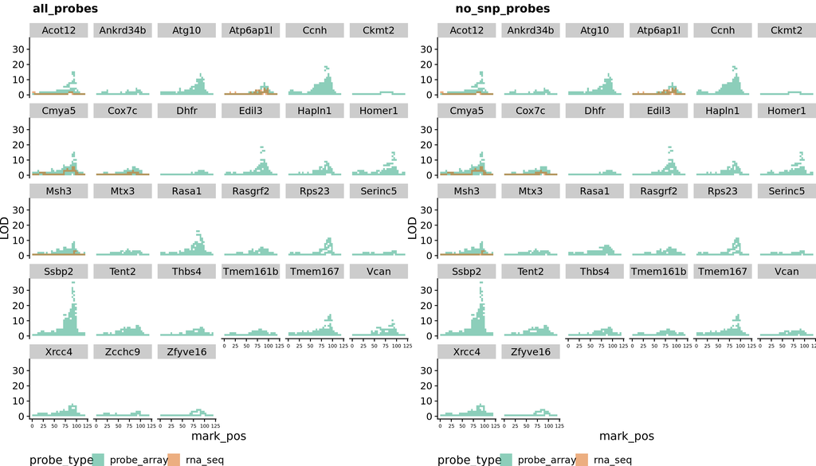

```r
    probesets = c('all_probes', 'no_snp_probes') %>% set_names(.)
    p_list = map(probesets, function(.x) {
        best_trace_recomb[[.x]] %>%
            semi_join(eqtl_dset_genes[[.x]], by = c("GN", "probe", "gene_name")) %>%
            ggplot(aes(mark_pos, LOD, fill = probe_type)) +
            geom_bin2d(alpha = 0.5) +
            facet_wrap(~gene_name) +
            scale_fill_brewer(palette = 'Dark2') +
            theme_half_open() +
            theme(plot.title = element_text(size = 10, hjust = 0.5),
                  plot.margin = margin(t = 1, unit = 'cm'),
                  legend.position = 'bottom',
                  axis.text.x = element_text(size = 6))
    })
    # identical(p_list[[1]], p_list[[2]])
    p = plot_grid(plotlist = p_list, nrow = 1, labels = probesets, vjust = 1.5)
    p
```

```r
    ggsave('test.pdf', p, w = 14, h = 8)
```

## 12.2 One trace per GN/probe pair

```r
    p_list = map(probesets, function(.x) {
        best_trace_recomb[[.x]] %>%
            semi_join(eqtl_dset_genes[[.x]], by = c("GN", "probe", "gene_name")) %>%
            ggplot(aes(mark_pos, LOD, color = str_c(GN, '_', probe))) +
            geom_step(alpha = 0.5) +
            scale_color_viridis_d() +
            theme_half_open() +
            theme(plot.title = element_text(size = 10, hjust = 0.5),
                  plot.margin = margin(t = 1, unit = 'cm'),
                  legend.position = 'none',
                  axis.text.x = element_text(size = 6))
    })
    # identical(p_list[[1]], p_list[[2]])
```

### 12.2.1 Fixed y-axis

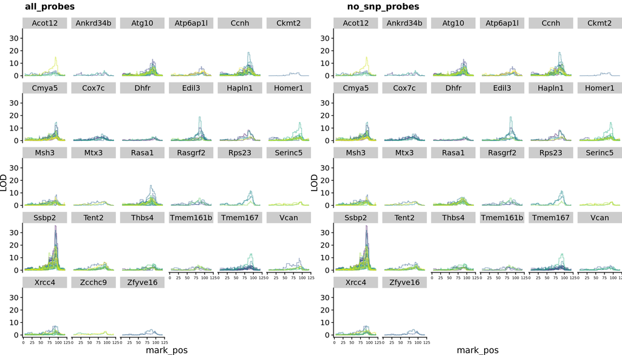

```r
    p = plot_grid(plotlist = map(p_list, ~.x + facet_wrap(~gene_name)),
                  nrow = 1, labels = probesets, vjust = 1.5)
    p
```

```r
    ggsave('test.pdf', p, w = 14, h = 8)
```

### 12.2.2 Free y-axis scale

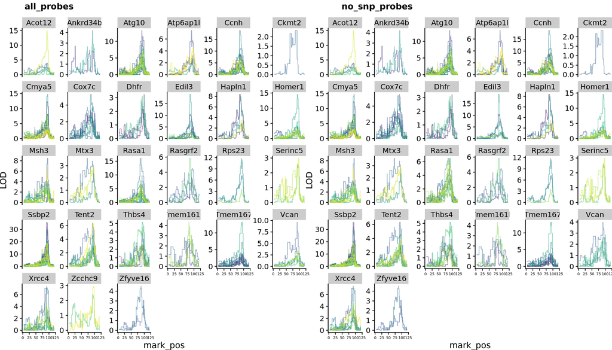

```r
    p = plot_grid(plotlist = map(p_list, ~.x + facet_wrap(~gene_name, scales = 'free_y')),
                  nrow = 1, labels = probesets, vjust = 1.5)
    p
```

```r
    ggsave('test.pdf', p, w = 14, h = 8)
```

# 13 Select dataset w/ >= 30 strains

```r
    strains_per_dset = BXDstrs::dset_strains %>%
        # filter in only sequenced ones
        semi_join(BXDstrs::strain_info %>% filter(is_seq_str), by = c('strain' = 'bxd_id')) %>%
        count(GN, name = 'n_strains') %>%
        filter(GN %in% sel_dsets)

    # select data sets that we think are reliable
    filt_dsets = strains_per_dset %>%
        filter(n_strains >= 30) %>%
        distinct(GN)
```

# 14 Calculate GNs per gene

A couple of genes that are features in fewer than 1/2 of datasets

```r
    # NOTE: use the "all" data.frame here because we want to have same gene set compared between "all" and "no_snp_probes"
    gn_per_gene = best_point_recomb$all %>%
        distinct(GN, gene_name) %>%
        mutate(n_gn = GN %>% unique %>% length) %>%
        count(gene_name, n_gn) %>%
        mutate(prop = n/n_gn)
    gn_per_gene %>% filter(prop < 0.5)
```

| gene_name | n_gn | n | prop |
| --- | --- | --- | --- |
| Ankrd34b | 54 | 19 | 0.35185185 |
| Atp6ap1l | 54 | 19 | 0.35185185 |
| Fam151b | 54 | 18 | 0.33333333 |
| Gm20379 | 54 | 2 | 0.03703704 |

```r
    # apply filter
    best_point_recomb_filt = map(best_point_recomb,
        ~.x %>% filter(!gene_name %in% (gn_per_gene %>% filter(prop < 0.5) %>% pull(gene_name))))
```